# PH784 Advanced Social Epidemiology: Methods

Week 7: Mediation & Review

Koichiro Shiba

kshiba@bu.edu

Boston University School of Public Health

October 20, 2025

## Today’s Plan

1. Simulating disparities
2. Mediation
   - Basics
   - Applications in social epi
   - Connecting back to 1
3. High-level Review

## Let’s Step Back: Anatomy of Causal Estimand

$$E[Y^{a=1}]-E[Y^{a=0}]$$

**This comparison is defined based on the choice of:**

1. Hypothetical interventions to define potential outcomes
   - Well-defined treatment, directionality, regimen (time-varying, dynamic, stochastic)
2. Study population (e.g., mean among whom?)
   - Subpopulation: ATE vs CATE, ATT, ATC, etc
3. Reference (e.g., $a=0$)
   - vs natural course
4. Summary measure (e.g., mean difference)

## Summarizing Changes in Population Health

### Distribution beyond mean

[figure not shown]

- Hypothetical interventions may have:
  - Same “effect” on average population health
  - Different implications for distributions
    - i.e., health disparities

Shifting the definition of “causal effect”

- “How would the hypothetical intervention change health disparities?”
  - e.g., $(E[Y^{A^g}|SES=high] - E[Y^{A^g}|SES=low]) - (E[Y|SES=high] - E[Y|SES=low])$
    - for stochastic intervention $A^g$
  - “The gap-closing estimand” (Lundberg 2024)
  - Example: Social isolation and social inequalities in all-cause mortality (Lunar et al. 2025)

## Population Interventions and Health Disparity

- Interventions may alter health disparities across social groups via:
  - Socially patterned effect heterogeneity
    - $E[Y^{a=1}-Y^{a=0}|L=l] \neq E[Y^{a=1}-Y^{a=0}|L=l^*]$
    - Narrow disparities if more beneficial among minoritized groups
    - Widen disparities if less beneficial among minoritized groups
  - Disproportionate change in exposure distribution
    - If minoritized groups experienced greater changes in exposure, they benefit more
    - Ignored in the “all treated” scenario of CATE

**Estimating CATEs alone is inadequate**

When do interventions result in disproportionate change in exposure?

Read Ward et al. (2019) for more discussion on this.

## Population Interventions and Health Disparity

### When do interventions disproportionately change exposure distributions?

- Existing exposure disparity
  - More prevalent among the low SES group
  - Even the same relative reduction would result in greater absolute reduction
    - e.g., reducing exposure by half
      - 60% to 30% (30 percentage points reduction)
      - 40% to 20% (20 percentage points reduction)

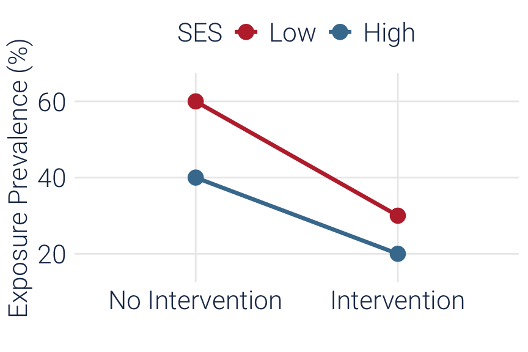

- Disproportionate reduction in the exposure
  - Even when there is no exposure disparity
    - Exposure prevalence 60% in both SES groups
      - 60% to 15% (quarter)
      - 60% to 30% (half)
    - Distinguish this from effect heterogeneity
  - *Example?*
    - Water fluoridation

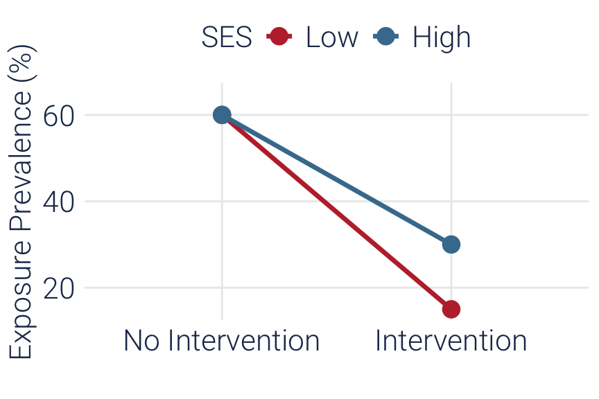

## Population Interventions and Health Disparity

### How do we simulate effects on health disparities rather than average health?

- Key ingredients of health disparities
  - Effect heterogeneity
    - $E[Y^{a=1}-Y^{a=0}|L=l] \neq E[Y^{a=1}-Y^{a=0}|L=l^*]$
  - Disproportionate changes in exposure
    - How do we incorporate disproportionate changes in exposure in causal estimand?
    - Stochastic intervention
      - Various estimators (e.g., Muñoz and Van Der Laan 2012)
        - e.g., Standardization (as in Ahern et al. 2016)

## Population Interventions and Health Disparity

### How do we simulate effects on health disparities rather than average health?

| $ID$ | $Y$ | $A$ | $L$ | $\tau(L)$ | $a=1$ | $a=0$ | $Y^{a=1}$ | $Y^{a=0}$ |
| --- | --- | --- | --- | --- | --- | --- | --- | --- |
| 1 | $Y_1$ | 1 | $\ell_1$ | $\tau_1$ | 1 | 0 | $Y_1$ | $Y_1 - \tau_1$ |
| 2 | $Y_2$ | 0 | $\ell_2$ | $\tau_2$ | 1 | 0 | $Y_2 + \tau_2$ | $Y_2$ |
| 3 | $Y_3$ | 0 | $\ell_3$ | $\tau_3$ | 1 | 0 | $Y_3 + \tau_3$ | $Y_3$ |
| $\dots$ | $\dots$ | $\dots$ | $\dots$ | $\dots$ | $\dots$ | $\dots$ | $\dots$ | $\dots$ |
| n | $Y_n$ | $A_n$ | $\ell_n$ | $\tau_n$ | 1 | 0 | $Y_n + (1 - A_n)\tau_n$ | $Y_n - A_n\tau_n$ |

- Simple standardization for static interventions
  - #1 Assign everyone to be treated $a=1$ (6th column) and untreated $a=0$ (7th column)
  - #2 Predict potential outcome under each scenario ($Y^{a=1}$ & $Y^{a=0}$)
    - Based on estimated effects $\tau_i$
  - #3 Calculate mean of $Y^{a=1}$ and mean of $Y^{a=0}$ across all individuals
  - #4 Calculate the difference between the two means & bootstrap
    - ATE: $E[Y^{a=1}]-E[Y^{a=0}]$

## Population Interventions and Health Disparity

### How do we simulate effects on health disparities rather than average health?

| $ID$ | $Y$ | $A$ | $L$ | $\tau(L)$ | $A^g$ | $Y^{A^g}$ |
| --- | --- | --- | --- | --- | --- | --- |
| 1 | $Y_1$ | 1 | $\ell_1$ | $\tau_1$ | 1 | $Y_1$ |
| 2 | $Y_2$ | 0 | $\ell_2$ | $\tau_2$ | 0 | $Y_2$ |
| 3 | $Y_3$ | 0 | $\ell_3$ | $\tau_3$ | 1 | $Y_3 + \tau_3$ |
| $\dots$ | $\dots$ | $\dots$ | $\dots$ | $\dots$ | $\dots$ | $\dots$ |
| n | $Y_n$ | $A_n$ | $\ell_n$ | $\tau_n$ | $A^g_i$ | $Y_n + (A^g_i - A_n)\tau_n$ |

- Standardization for stochastic interventions
  - #1 Assign exposure distributions under a stochastic intervention of interest
    - e.g., randomly removing exposure by 50%
    - e.g., lowering propensity scores by 50%
  - #2 Predict potential outcome $Y^{A^g}$ based on estimated effects $\tau_i$
  - #3 Calculate mean of $Y^{A^g}$ and mean of observed outcome $Y$ across all individuals
  - #4 Calculate the difference between the two means & bootstrap
    - Stochastic intervention effect: $E[Y^{A^g}]-E[Y]$
      - compared to “no intervention”

## Population Interventions and Health Disparity

### How do we simulate effects on health disparities rather than average health?

| $ID$ | $Y$ | $A$ | $L$ | $\tau(L)$ | $A^g$ | $Y^{A^g}$ |
| --- | --- | --- | --- | --- | --- | --- |
| 1 | $Y_1$ | 1 | $\ell_1$ | $\tau_1$ | 1 | $Y_1$ |
| 2 | $Y_2$ | 0 | $\ell_2$ | $\tau_2$ | 0 | $Y_2$ |
| 3 | $Y_3$ | 0 | $\ell_3$ | $\tau_3$ | 1 | $Y_3 + \tau_3$ |
| $\dots$ | $\dots$ | $\dots$ | $\dots$ | $\dots$ | $\dots$ | $\dots$ |
| n | $Y_n$ | $A_n$ | $\ell_n$ | $\tau_n$ | $A^g_i$ | $Y_n + (A^g_i - A_n)\tau_n$ |

- Standardization for stochastic interventions on health disparities
  - #1 Assign exposure distributions under a stochastic intervention of interest
  - #2 Predict potential outcome $Y^{A^g}$ based on estimated effects $\tau_i$
  - #3 Calculate disparities in $Y^{A^g}$ and disparities in observed outcome $Y$
  - #4 Calculate the difference between the two disparities & bootstrap
    - e.g., $(E[Y^{A^g}|SES=high] - E[Y^{A^g}|SES=low]) - (E[Y|SES=high] - E[Y|SES=low])$
      - “How would the hypothetical intervention change SES-based health disparities?”
    - “The Gap-closing Estimand” (Lundberg 2024) or “Disparity Treatment Effect” (Shiba)
      - Example: Social isolation and social inequalities in all-cause mortality (Lunar et al. 2025)

## Summary 1

- Two key ingredients of health disparities
  - Effect heterogeneity
  - Exposure disparities
    - Often ignored by considering the “all exposed vs unexposed” scenarios
- Standardization to predict potential outcome distributions under hypothetical stochastic interventions
  - Consider estimand that explicitly captures changes in disparities
  - Disparity effect

## Mediation Analysis

### Two effects in mediation analyses

[figure not shown]

- Indirect Effect
  - Effect of exposure $A$ through mediator $M$
- Direct effect
  - Effect of exposure $A$ that is independent of mediator $M$
    - Various definitions depending on the motivation
    - Should be chosen based on causal estimand of interest.

**Motivation for Causal Mediation Analysis**

- #1 Target of interventions
  - Particularly useful when “exposure” is hard to manipulate
- #2 Effect decomposition
  - Explaining what explains the effect that we are observing
  - Strengthening theory and generating hypotheses

## Naive Approach: Difference Method

### Example: Linear regression of outcome $\color{#457b9d}{Y}$ on exposure $\color{#457b9d}{A}$ adjusting for confounders $\color{#457b9d}{L_A}$

[figure not shown]

- Model 1: $E[Y|A, L_A] = \beta_0 + \beta_1A + \beta L_A$
  - $\beta_1$: Total effect of $A$ on $Y$ (within strata of $L_A$)
    - Assuming exchangeability conditional on $L_A$

[figure not shown]

- Model 2: $E[Y|A, M, L_A] = \gamma_0 + \color{#be2f3a}{\gamma_1} \color{#1d3557}{A + \gamma_2M + \gamma L_A}$
  - Additionally adjust for mediator $M$
    - Attenuation as “evidence of mediation”
  - $\color{#be2f3a}{\gamma_1}$: Effect of $A$ conditional on $M$
    - Effect that is independent of $M$
    - Direct effect
  - $\color{#457b9d}{\beta_1 - \gamma_1}$: Effect of $A$ through $M$
    - Indirect Effect

**Any potential issue?**

## Naive Approach: Difference Method

### Example: Linear regression of outcome $\color{#457b9d}{Y}$ on exposure $\color{#457b9d}{A}$ adjusting for confounders $\color{#457b9d}{L_A}$

[figure not shown]

- Model 2: $E[Y|A, M, L_A] = \gamma_0 + \gamma_1 A + \gamma_2M + \gamma L_A$
  - $\gamma_1$: Association between $A$ and $Y$ conditional on $M$
    - $M$ as a collider
      - Selection bias through mediator-outcome confounders $L_M$
    - Ignored exposure-mediator interaction $A \times M$

[figure not shown]

- Model 3: $E[Y|A, M, L_A, L_M] = \theta_0 + \color{#be2f3a}{\theta_1} \color{#1d3557}{A + \theta_2M + \theta_3 A \times M} + \theta L_A + \delta L_M$
  - $\theta_1: E[Y|A=1, M=0, L_A, L_M] - E[Y|A=0, M=0, L_A, L_M]$

**Corresponding causal estimand?**

- $E[Y^{a=1, m=0}-Y^{a=0, m=0}|L_A, L_M]$ under conditional exchangeability for BOTH $A$ and $M$
  - “The effect of $A$ while fixing the mediator to $m=0$”
    - Joint intervention for both $A$ and $M$
    - Controlled Direct Effect

## Causal Mediation Analysis

- Naive regression analysis is often:
  - Based on strong and potentially incorrect assumptions
  - Vague or potentially irrelevant causal estimand
- Causal mediation analysis
  - First, define Direct/Indirect Effects based on potential outcomes
    - CDE, NDE, IDE, etc
  - Second, consider identification assumptions
  - Third, estimate the target statistical estimand
    - Can be regular outcome regression
      - if assumptions are valid and corresponding estimand is of interest
    - But also flexible estimation via weighting, machine learning, etc

## Controlled Direct Effect

- Total Effect: $TE = E[Y^{a=1}-Y^{a=0}]$
- Controlled Direct Effect: $CDE(m)=E[Y^{a=1,m}-Y^{a=0,m}]$
  - Function of a specific mediator value $m$
- “Proportion eliminated”: $(TE-CDE(m))/TE$
  - How much of the total effect of $A$ would be eliminated if we intervened and fixed mediator value to $m$ for everyone?

[figure not shown]

- CDE as a joint intervention for $A$ and $M$
  - Can be viewed as time-varying treatment analysis
  - CDE can be identified in the presence of exposure-induced confounding: $A \rightarrow L_M$
    - Adjusting for time-dependent confounding via g-methods
    - e.g., “Causal mediation via marginal structural model” (Nandi et al. 2012)

## “Hypothetical Mediator Intervention”

- Controlled Direct Effect: $CDE(m)=E[Y^{a=1,m}-Y^{a=0,m}]$
  - Joint intervention that also fixes mediator to a specific value $m$
    - Deterministic intervention for $M$
    - Different $CDE(m)$ estimates across $m$ values with the exposure-mediator interaction
  - How do we choose a meaningful $m$ value?
    - Policy relevance (might be feasible with a binary $M$)
    - But hard to pick a single value for $M$ with numerous levels
      - e.g., fixing PM2.5 to $9 \mu g/m^3$ for everyone

**Alternative hypothetical mediator intervention**

- A random draw from a distribution of mediator values $\mathcal{M}$
  - e.g., $\mathcal{M}(a|L)$
  - “Distribution of mediator values that would have been observed among people like you (in terms of covariates $L$) had they received treatment $a$”

## “Hypothetical Mediator Intervention” for a Mediator Distribution

- Interventional Direct Effect
  - $IDE = E[Y^{a=1, \mathcal{M}(0|L)}-Y^{a=0, \mathcal{M}(0|L)}]$
    - Exposure effect that would be observed while fixing the *distribution* of mediator values
      - Distribution under $a=0$ conditional on $L$
      - Additionally require no A-M confounding assumption
    - Can also be defined as $IDE = E[Y^{a=1, \mathcal{M}(1|L)}-Y^{a=0, \mathcal{M}(1|L)}]$
  - Non-zero $IDE$
    - Suggests the presence of effect of $A$ that is independent of $\mathcal{M}$
      - Hence, direct effect
- Extending causal inference for distributional interventions (see Lecture 5) to mediation
  - Stochastic interventional effect (Rudolph et al. 2018)
    - aka interventional effects, randomized interventional analogs
  - Flexible specification of $\mathcal{M}$

## Extension to Health Disparity Research

[figure not shown]

- Example in Nguyen et al. (2021)
  - Y: Wellbeing
  - M: Bullying
  - A: Sexual minority
- Observed disparity:
  - $\mathcal{D}=E[Y|A=1]-E[Y|A=0]$
- Counterfactual disparity under a hypothetical intervention ($A^g$) equalizing the level of bullying $\mathcal{M}$ among sexual minority to the level experienced by majority (i.e., $\mathcal{M}(0)$)
  - $\mathcal{D}^{A^g}=E[Y^{\mathcal{M}(0)}|A=1]-E[Y|A=0]$
- “Decomposing” disparity
  - $\mathcal{D}= E[Y|A=1]-E[Y|A=0]$
    - $= E[Y|A=1] - E[Y^{\mathcal{M}(0)}|A=1] + E[Y^{\mathcal{M}(0)}|A=1]-E[Y|A=0]$
    - $= E[Y|A=1] - E[Y^{\mathcal{M}(0)}|A=1] + \mathcal{D}^{A^g}$

Nguyen et al. (2021) used the notation $E[Y^{1, \mathcal{M}(0,C)}|A=1,C]-E[Y|A=0,C]$ for $\mathcal{D}^{A^g}$, which I think is a typo because they conceptualized no hypothetical intervention for sexual minority status. Also note that their estimand is conditional on covariates $C$. A marginal rather than conditional distribution $\mathcal{M}$ may be more preferable in disparity research - see their footnote #22.

## Extension to Health Disparity Research

- “Decomposing” disparity
  - $\mathcal{D}= E[Y|A=1] - E[Y^{\mathcal{M}(0)}|A=1] + \mathcal{D}^{A^g}$
    - Observed disparity = “Disparity-removed” + Remaining disparity under an intervention
- Causal inference for health disparity
  - Often viewed as an extension of effect decomposition/mediation
  - But the causal estimand involves no counterfactual for the “exposure”
    - e.g., no conceptualization of “race effect”
      - Avoid the potential consistency concern for the “exposure”
        - No components corresponding to “direct/indirect effects”
      - (My view) a more general extension of stochastic intervention effect rather than mediation

**Which is more relevant?**

- The decomposition?
- The expected change in disparity (i.e., $\mathcal{D} - \mathcal{D}^{A^g}$)?
  - The “Gap-closing Estimand” (Lundberg 2024) or “Disparity (Treatment) Effect” (Shiba)

## Disparity Effect and Effect Decomposition

- Example from this slide
- “Disparity effect”
  - $(E[Y^{A^g}|SES=high] - E[Y^{A^g}|SES=low]) - (E[Y|SES=high] - E[Y|SES=low])$
    - “How would the hypothetical intervention change SES-based health disparities?”
    - e.g., what if the distribution of $A$ among $SES=low$ is identical to that of $SES=high$
      - Can conceptualize alternative interventions more flexibly
      - Simulating how interventions may change “exposure disparities” (see this slide)

**Different notation/estimand but same idea**

- Mediation would have conceptualized SES as an “exposure”
  - Here, the “exposure” is what mediation would conceptualize as a mediator ($M$)
    - Correspond better to conceptualized hypothetical interventions ($A^g$)
      - Manipulating the distribution of $A$ while conducting no explicit intervention for SES
- More explicit focus on consequence rather than explanation
- Can incorporate “allowability” (Jackson 2021)

## Disparity Effect and Effect Decomposition

- Framing & terminology do not matter as long as you are:
  - Explicit about causal estimand of interest
  - Explicit about a hypothetical intervention under consideration
    - Social identity as a factor that defines disparity rather than an interventional target
- Many estimators
  - Standardization
    - Explicit focus on the two key ingredients of disparity
      - Effect heterogeneity & exposure disparities
      - Potentially different insights depending on which is the primary driver
  - IPW
  - Doubly-robust
    - Modeling of the ingredients tended to be avoided or treated implicitly as intermediate estimation steps

## Disparity Effect and Effect Decomposition

### Further readings

- On the importance of heterogeneity in disparity research
  - Ward et al. (2019) & Shiba and Inoue (2024)
- Decomposition/mediation framework
  - Jackson and VanderWeele (2018), Jackson (2021), Jackson and VanderWeele (2019)
  - Comprehensive summary by Qin and Jackson (2025) & Chang et al. (2024)
  - On using CDE in disparity research by Naimi et al. (2016)
  - Non-parametric approach by Yu and Elwert (2025)
- More general disparity estimand
  - Excellent review by Opacic et al. (2025)
  - “Gap-closing estimand” by Lundberg (2024)
  - Recent development by Jackson et al. (2024)
  - Wang *et al* (forthcoming)

## Simulating Disparity Effects: An Applied Example

### Social isolation and cognitive functioning of older adults (from Lecture 6)

- Data: Health and Retirement Study (n=11,322)
- Exposure: Social isolation (dichotomized composite index)
  - Marital status and cohabitation
  - Contact with children, family, and friends
  - Social participation
- Outcome: Cognitive functioning (TICS; 0-27 points)
- Covariates: 35 pre-baseline covariates
- Analysis:
  - Non-parametric estimation of CATE ($E[Y^{a=1}-Y^{a=0}| L]$) via Causal Forest
  - Simulated changes in disparities in cognitive functioning using the standardization approach described in this slide

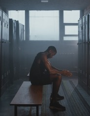

Unpublished results from Wang *et al* (forthcoming)

## Observed Outcome Disparities

- Lower income was associated with lower levels of cognitive functioning

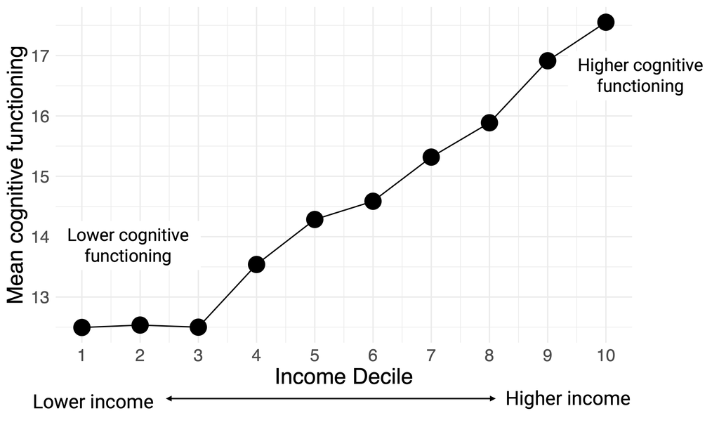

Unpublished results from Wang *et al* (forthcoming)

## Ingredient 1: Exposure Disparity

- Lower income was associated with higher prevalences of social isolation
  - Same trends for wealth, education, and race and ethnicity
    - Socially marginalized groups are more likely to be *exposed* to social isolation

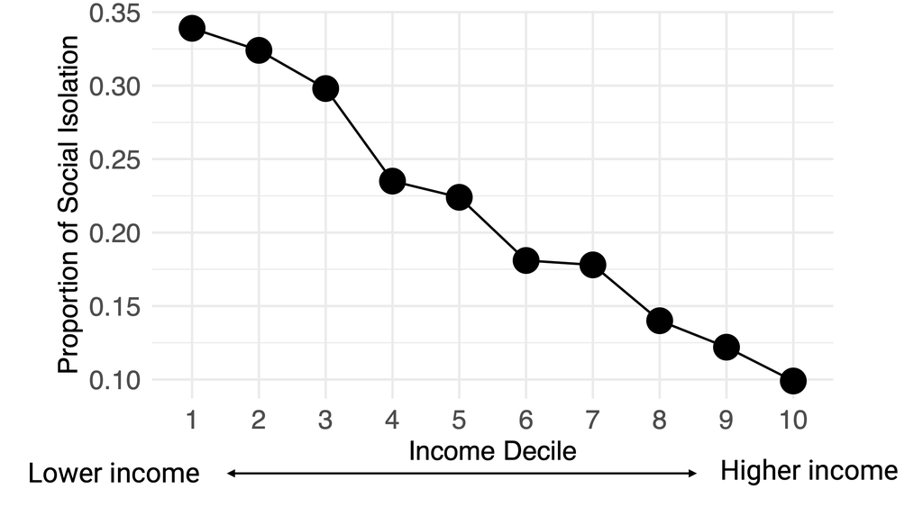

Unpublished results from Wang *et al* (forthcoming)

## Ingredient 2: Effect Heterogeneity

- Socially marginalized groups are *harmed* more severely by social isolation
  - Despite the notable trend by intersections of high income and other forms of social marginalization (small in size)

[figure not shown]

Unpublished results from Wang *et al* (forthcoming)

## Hypothetical Interventions

- Interventions that remove social isolation among the exposed
  - Explicitly addressing exposure disparities
  - Preserve exposure disparities while reducing the population-wide prevalence

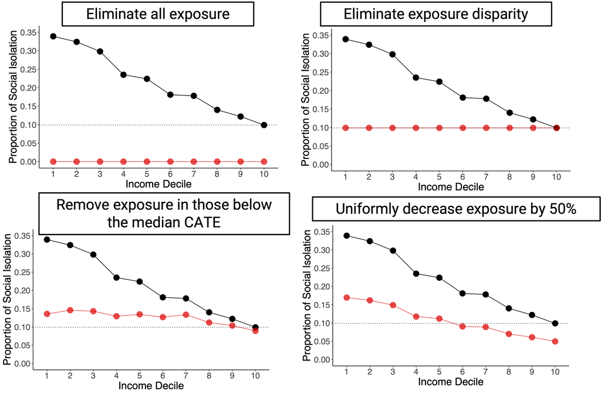

Unpublished results from Wang *et al* (forthcoming)

## Simulated Disparity Effects

- Population interventions for social isolation would reduce income-based disparities in cognitive functioning
  - Same trend for wealth, education, and race and ethnicity
  - Particularly so when the intervention explicitly addresses exposure disparities

[figure not shown]

Unpublished results from Wang *et al* (forthcoming)

## Summary 2

- Controlled Direct Effect (CDE)
  - Joint intervention for both exposure and mediator
    - Fixing mediator to a specific value
  - Conditional exchangeability assumptions
    - No A-Y confounding, no M-Y confounding
- Interventional Direct Effect (IDE)
  - Joint intervention for both exposure and mediator
    - Setting a mediator distribution
  - Conditional exchangeability assumptions
    - Same as CDE + no A-M confounding
- Disparity Effect
  - Extension of stochastic intervention analysis
  - Can be also viewed as “effect” decomposition
    - But no causal “effect” conceptualized for exposure

## Mediation for Effect Decomposition

- CDE as a joint intervention
  - “What is the remaining effect of $A$ if I fix $M$ to $m$ via an intervention?”
    - Does not capture the extent to which mediator *explains* the exposure effect that they would experience without the mediator intervention
    - … because people may take various mediator values under the intervention $A \rightarrow a$
      - Counterfactual mediator values $M^{a}$
      - Mediator level that a *person* would have naturally experienced had the *person* received $a$
- Natural Direct Effect
  - $NDE=E[Y^{a=1,M^1}]-E[Y^{a=0,M^1}]$
    - Can be also defined as $E[Y^{a=1,M^0}]-E[Y^{a=0,M^0}]$
  - What is the remaining effect of $A$ if mediator is set to the same level for each individual?
    - Hence, direct effect

## Identification for Natural Effects

- Conceptualizing the potential outcome $Y^{a,M^{a^*}}$
  - Involves the effect of A on M
    - Another set of identification assumptions
      - Conditional exchangeability, consistency, and positivity for the A-M relationship
  - Two different counterfactuals embedded simultaneously
    - “Cross-world independence”
      - Additional assumption: No exposure-induced M-Y confounding

**NDE/NIE requires stronger assumptions than CDE**

## Mediation for Effect Decomposition

- Total effect $TE=E[Y^{a=1}]-E[Y^{a=0}]$
  - $TE = E[Y^{a=1,M^1}]- E[Y^{a=0,M^0}]$ by consistency for the effect of $A$ on $M$
  - $E[Y^{a=1,M^1}]-E[Y^{a=0,M^1}] + E[Y^{a=0,M^1}] - E[Y^{a=0,M^0}]$
  - $NDE + NIE$
- “Natural Indirect Effect (NIE)”
  - The magnitude of exposure effect mediated through $M$
  - “Proportion mediated”: $NIE/TE$
    - Distinguish this from “proportion eliminated” in this slide
      - Read VanderWeele (2013) on their differences
- Effect can be decomposed into smaller componenents
  - e.g., separating effects attributable to effect heterogeneity or mediation
  - Can be useful to test alternative hypotheses about mechanisms
    - e.g., life course epidemiology (Yazawa et al. 2022)

## Summary 3

- Natural Direct Effect (NDE)
  - Definition based on cross-world counterfactuals
  - Useful for effect decomposition
    - Understanding mechanisms
  - Conditional exchangeability assumptions
    - No A-Y confounding, no A-M confounding, no M-Y confounding affected by A (i.e., no exposure-induced confounding)
- CDE vs NDE vs IDE, etc
  - Know differences in definitions (estimand), identification assumptions, implications
  - Helpful tutorials: VanderWeele (2016) & Nguyen et al. (2021) & Nguyen et al. (2022)

## How to Critically Assess Methodology in (Social) Epi Papers

[figure not shown]

- #1. Identify causal question under consideration
  - Often vague or not useful
    - e.g., not specifying time interval
  - Is it well-justified?
    - e.g., Using g-methods when a single-point intervention is sufficient
- #2. Check correspondence between what they examined vs what they claim they did
  - Discrepancy may arise from:
    - Statistical approach (e.g., using IV without claiming complier effects)
    - Measurement with a conceptual validity issue

## How to Critically Assess Methodology in (Social) Epi Papers

[figure not shown]

- #3. Assess the validity of underlying assumptions
  - Causal identifications
    - Conditional exchangeability & consistency
  - Modeling assumptions (e.g., linearity)
- #4 Check correspondence between numeric estimates and their interpretation
  - e.g., interpreting effect heterogeneity as causal interaction
    - Did they discuss alternative explanations? (e.g., multiple versions of treatment)
  - e.g., no association with baseline exposure as evidence of no effect at all
    - absence of evidence is not evidence of absence
    - but also potential non-adherence (i.e., time-varying treatment)

## When You Learn Methods

[figure not shown]

- It is all about trade-off
  - No single “winning” method
  - Fancy methods $\neq$ better methods
  - Consider estimand and assumptions
    - More relevant estimand & stronger assumptions vs vague estimand & weaker assumptions
- Distinguish identification and estimation
  - Which of these two is the method improving?
  - e.g., “Propensity score matching can estimate causal effects”
  - e.g., “Machine learning methods must not be used in causal inference”

## When You Learn Methods

- Focus on mathematically defined causal estimand
  - Try not to be obsessed with terminology
    - e.g., effect modification, effect heterogeneity, causal estimand
  - Often overlapping concepts and methods but different terminology
    - e.g., Controlled direct effect as a time-varying treatment effect
    - e.g., Causal interaction as a joint intervention
      - Can use the time-varying treatment analysis when conceptualizing a joint intervention for temporally separated targets
    - e.g., disparity effect vs “effect” decomposition/mediation

**Always keep in mind**

- Many different approaches to the same problem
- There is no single “correct” view/approach
  - Be flexible and creative

## Announcements

- Final Assignment (due October 24th at 11:59 PM)
- Course survey
  - Formal and informal surveys
- Photo & Marketing
- Research projects

## References

Ahern J, Colson KE, Margerson-Zilko C, Hubbard A, Galea S. Predicting the population health impacts of community interventions: The case of alcohol outlets and binge drinking. American journal of public health. 2016;106(11):1938–43.

Chang TH, Nguyen TQ, Jackson JW. The importance of equity value judgments and estimator-estimand alignment in measuring disparity and identifying targets to reduce disparity. American journal of epidemiology. 2024;193(3):536–47.

Jackson JW. Meaningful causal decompositions in health equity research: Definition, identification, and estimation through a weighting framework. Epidemiology. 2021;32(2):282–90.

Jackson JW, Hsu YJ, Zalla LC, Carson KA, Marsteller JA, Cooper LA, et al. Evaluating effects of multilevel interventions on disparity in health and healthcare decisions. Prevention science. 2024;25(Suppl 3):407–20.

Jackson JW, VanderWeele TJ. Decomposition analysis to identify intervention targets for reducing disparities. Epidemiology. 2018;29(6):825–35.

Jackson JW, VanderWeele TJ. Intersectional decomposition analysis with differential exposure, effects, and construct. Social Science & Medicine. 2019;226:254–9.

Lunar FR, Kondo N, Honda Y, Nakagomi A, Komura T, Inoue K, et al. Sociodemographic heterogeneity in the association between social isolation and all-cause mortality among japanese older adults: JAGES longitudinal panel study. Lancet Reg Health West Pac. 2025 Oct;63.

Lundberg I. The gap-closing estimand: A causal approach to study interventions that close disparities across social categories. Sociological Methods & Research. 2024;53(2):507–70.

Muñoz ID, Van Der Laan M. Population intervention causal effects based on stochastic interventions. Biometrics. 2012;68(2):541–9.

Naimi AI, Schnitzer ME, Moodie EE, Bodnar LM. Mediation analysis for health disparities research. American journal of epidemiology. 2016;184(4):315–24.

Nandi A, Glymour MM, Kawachi I, VanderWeele TJ. Using marginal structural models to estimate the direct effect of adverse childhood social conditions on onset of heart disease, diabetes, and stroke. Epidemiology. 2012;23(2):223–32.

Nguyen TQ, Schmid I, Ogburn EL, Stuart EA. Clarifying causal mediation analysis: Effect identification via three assumptions and five potential outcomes. Journal of Causal Inference. 2022;10(1):246–79.

Nguyen TQ, Schmid I, Stuart EA. Clarifying causal mediation analysis for the applied researcher: Defining effects based on what we want to learn. Psychological methods. 2021;26(2):255.

Opacic A, Wei L, Zhou X. Disparity analysis: A tale of two approaches. Journal of the Royal Statistical Society Series A: Statistics in Society. 2025;qnaf008.

Qin MM, Jackson JW. A review of the causal decomposition framework for modeling interventions that reduce disparities. Current epidemiology reports. 2025;12(1):10.

Rudolph KE, Sofrygin O, Zheng W, Van Der Laan MJ. Robust and flexible estimation of stochastic mediation effects: A proposed method and example in a randomized trial setting. Epidemiologic Methods. 2018;7(1):20170007.

Shiba K, Inoue K. Harnessing causal forests for epidemiologic research: Key considerations. American Journal of Epidemiology. 2024;193(6):813–8.

VanderWeele TJ. Policy-relevant proportions for direct effects. Epidemiology. 2013;24(1):175–6.

VanderWeele TJ. Mediation analysis: A practitioner’s guide. Annual review of public health. 2016;37(1):17–32.

Ward JB, Gartner DR, Keyes KM, Fliss MD, McClure ES, Robinson WR. How do we assess a racial disparity in health? Distribution, interaction, and interpretation in epidemiological studies. Annals of epidemiology. 2019;29:1–7.

Yazawa A, Shiba K, Inoue Y, Okuzono SS, Inoue K, Kondo N, et al. Early childhood adversity and late-life depressive symptoms: Unpacking mediation and interaction by adult socioeconomic status. Social psychiatry and psychiatric epidemiology. 2022;57(6):1147–56.

Yu A, Elwert F. Nonparametric causal decomposition of group disparities. The Annals of Applied Statistics. 2025;19(1):821–45.